# GA Audit Tool

# 1 Account Structure

## 1.1 Properties

The account, **Noise to Signal**, has 2 properties. These are shown below sorted by update date in reverse chronological order.

| Property | URL | Updated Date |
| --- | --- | --- |
| NtS Segment Test | http://noisetosignal.io | 2019-09-04 01:43:54 |
| www.noisetosignal.io | http://www.noisetosignal.io | 2015-07-29 14:10:10 |

## 1.2 Views

In total, there are 6 views. These are shown below in reverse chronological order by update date.

| View | Property | Update Date |
| --- | --- | --- |
| All Web Site Data | NtS Segment Test | 2019-09-04 01:43:54 |
| NTS Production | www.noisetosignal.io | 2019-06-28 18:44:31 |
| NTS Test | www.noisetosignal.io | 2019-06-28 18:44:31 |
| Test Mobile View | www.noisetosignal.io | 2018-04-24 12:49:31 |
| Only CD7 Foo=Bar Traffic | www.noisetosignal.io | 2017-11-30 13:40:20 |
| All Web Site Data | www.noisetosignal.io | 2015-05-14 15:55:28 |

The property with the most views is **www.noisetosignal.io** with 5 views. The number of views per property is below.

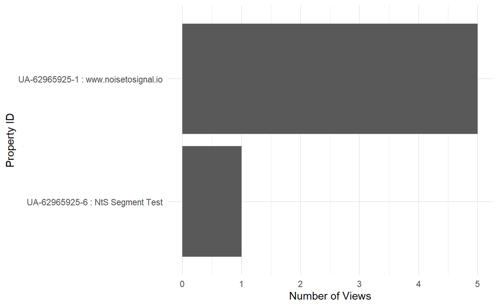

# 2 Configuration

## 2.1 Custom Dimensions

Property **www.noisetosignal.io** has 7 custom dimensions shown below:

| ID | Name | Scope | Is Active? |
| --- | --- | --- | --- |
| 1 | Logged In Status | SESSION | TRUE |
| 2 | Client ID | USER | TRUE |
| 3 | Open CPU Previous Predicted Path | HIT | TRUE |
| 4 | Open CPU Prediction Method | HIT | TRUE |
| 5 | Session ID | SESSION | TRUE |
| 6 | Hit Timestamp | HIT | TRUE |
| 7 | Foo | SESSION | TRUE |

## 2.2 Goals

### 2.2.1 All Goals (1)

View **NTS Production** has 1 goals listed below.

| Goal | Type | Is Active? |
| --- | --- | --- |
| >1 Page per Session | VISIT_NUM_PAGES | TRUE |

### 2.2.2 Destination Goals (0)

### 2.2.3 Event Goals (0)

## 2.3 Filters

### 2.3.1 All Filters (7)

View **NTS Production** has 7 filters listed below.

| Filter | Type |
| --- | --- |
| Referral Spam #1 | EXCLUDE |
| Include only traffic to www.noisetosignal.io | INCLUDE |
| Exclude Traffic from Adam IPv4 | EXCLUDE |
| Remove /wp-admin traffic | EXCLUDE |
| Exclude Traffic from Adam IPv6 | EXCLUDE |
| Exclude Logged In Users | EXCLUDE |
| Exclude NTS | EXCLUDE |

### 2.3.2 Include Filters (1)

Include/Exclude filters are called out below along with their criteria.

| Filter | Type | Criteria |
| --- | --- | --- |
| Include only traffic to www.noisetosignal.io | INCLUDE | PAGE_HOSTNAME EQUAL www.noisetosignal.io |

### 2.3.3 Exclude Filters (6)

Include/Exclude filters are called out below along with their criteria.

| Filter | Type | Criteria |
| --- | --- | --- |
| Referral Spam #1 | EXCLUDE | CAMPAIGN_SOURCE MATCHES floating-share-buttons.com\|www.Get-Free-Traffic-Now.com\|www.event-tracking.com\|fix-website-errors.com\|keywords-monitoring-your-success.com |
| Exclude Traffic from Adam IPv4 | EXCLUDE | GEO_IP_ADDRESS EQUAL 76.24.17.66 |
| Remove /wp-admin traffic | EXCLUDE | PAGE_REQUEST_URI MATCHES ^\\/wp-admin |
| Exclude Traffic from Adam IPv6 | EXCLUDE | GEO_IP_ADDRESS EQUAL 2601:184:4680:b39c:6d82:687b:4b6a:460c |
| Exclude Logged In Users | EXCLUDE | CUSTOM_DIMENSION MATCHES logged-in |
| Exclude NTS | EXCLUDE | GEO_IP_ADDRESS EQUAL 76.24.17.66 |

# 3 Data Integrity

## 3.1 Goal Measurement

### 3.1.1 Past 7 Days

| Goal | Completions |
| --- | --- |
| >1 Page per Session | 12 |

### 3.1.2 Past 30 Days

| Goal | Completions |
| --- | --- |
| >1 Page per Session | 114 |

### 3.1.3 Past 90 Days

| Goal | Completions |
| --- | --- |
| >1 Page per Session | 190 |

## 3.2 Hostname Review

In many cases, GA properties and views are capturing data from the wrong domain or sub-domain. As a reference, the URL associated with **NTS Production** is http://www.noisetosignal.io and the URL associated with its property is http://www.noisetosignal.io. These URLs are configured in the GA admin and don’t necessarily indicate which domains should be tracked.

Data has been retrieved for the last 30 days (2020-04-14 to 2020-05-14). Overall, 1 unique hostnames were discovered.

|  | hostname | sessions |
| --- | --- | --- |
| 1 | www.noisetosignal.io | 373 |

## 3.3 Events

### 3.3.1 Top Events

|  | Category | Action | Label | Events |
| --- | --- | --- | --- | --- |
| 1 | Page Visibility | change | visible => hidden | 547 |
| 2 | Capture Client ID | Capture Client ID Non-interaction | (not set) | 308 |
| 3 | Page Visibility | change | hidden => visible | 262 |
| 4 | Viewport | impression | contact-15-wp | 22 |
| 5 | Scroll Tracking | Page Bottom | / | 14 |
| 6 | Outbound Link | click | https://support.google.com/360suite/datastudio/answer/7287743?hl=en | 7 |
| 7 | Scroll Tracking | Page Bottom | /2017/02/how-to-add-segments-to-google-data-studio-reports/ | 3 |
| 8 | Scroll Tracking | Page Bottom | /portfolio/ | 3 |
| 9 | Outbound Link | click | https://github.com/BrightcoveOS/videojs-ga-videocloud | 2 |
| 10 | Outbound Link | click | https://github.com/BrightcoveOS/videojs-ga-videocloud/blob/master/README.md | 2 |

[output cut: 9 more lines]

### 3.3.2 Unique Event Categories

| Event Category | Total |
| --- | --- |
| Page Visibility | 809 |
| Capture Client ID | 308 |
| Scroll Tracking | 23 |
| Viewport | 22 |
| Outbound Link | 17 |

### 3.3.3 Unique Event Actions

| Event Action | Total |
| --- | --- |
| change | 809 |
| Capture Client ID Non-interaction | 308 |
| Page Bottom | 23 |
| impression | 22 |
| click | 17 |

### 3.3.4 Unique Event Labels

| Event Label | Total |
| --- | --- |
| visible => hidden | 547 |
| (not set) | 308 |
| hidden => visible | 262 |
| contact-15-wp | 22 |
| / | 14 |
| https://support.google.com/360suite/datastudio/answer/7287743?hl=en | 7 |
| /2017/02/how-to-add-segments-to-google-data-studio-reports/ | 3 |
| /portfolio/ | 3 |
| https://github.com/BrightcoveOS/videojs-ga-videocloud | 2 |
| https://github.com/BrightcoveOS/videojs-ga-videocloud/blob/master/README.md | 2 |

[output cut: 9 more lines]

# 4 Trends

## 4.1 All Traffic

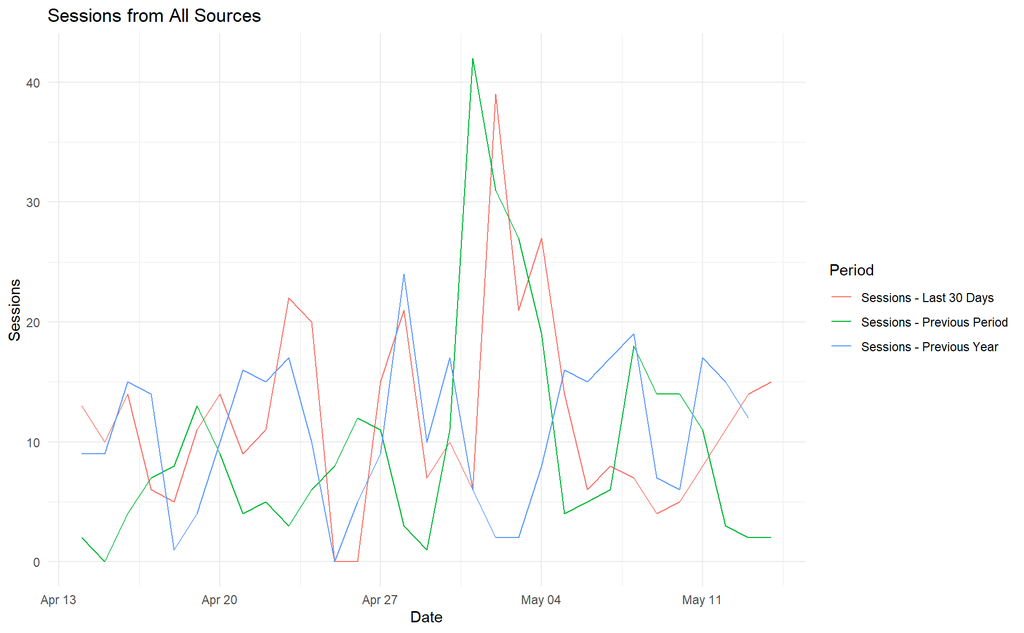

## 4.2 Landing Pages

Showing top 100 landing pages by number of sessions.

| Landing Page | Sessions | Bounce Rate | Avg Session Duration |
| --- | --- | --- | --- |
| / | 111 | 11.71171 | 118.3243 |
| /2017/02/how-to-add-segments-to-google-data-studio-reports/ | 93 | 56.98925 | 247.1613 |
| /2015/11/simplify-your-campaign-tagging-using-sitecore-and-google-tag-manager/ | 41 | 58.53659 | 329.9268 |
| /2016/02/deploying-autotrack-js-through-google-tag-manager/ | 30 | 46.66667 | 339.0000 |
| /2015/12/integrating-brightcoves-video-player-with-google-analytics/ | 22 | 40.90909 | 343.4545 |
| /2015/08/google-analytics-content-groups-unique-views-vs-sessions/ | 21 | 57.14286 | 318.2857 |
| /2016/11/using-google-analytics-to-predict-clicks-and-speed-up-your-website/ | 14 | 64.28571 | 183.4286 |
| /2016/11/using-google-analytics-to-predict-clicks-and-speed-up-your-website/?sa=D&ust=1522637949841000 | 10 | 60.00000 | 99.9000 |
| /2020/03/mobile-app-live-streaming-analytics-case-study-hope-channel/ | 9 | 66.66667 | 10.0000 |
| /2016/03/google-analytics-public-service-announcement-direct-traffic-is-unknown-traffic/ | 5 | 40.00000 | 266.2000 |

[output cut: 9 more lines]

## 4.3 Top Referral Sources

| sourceMedium | sessions | bounceRate | avgSessionDuration |
| --- | --- | --- | --- |
| bottraffic.host / referral | 65 | 0.00000 | 10.0000 |
| mail.google.com / referral | 11 | 18.18182 | 689.0909 |
| github.com / referral | 6 | 66.66667 | 114.5000 |
| guess-js.github.io / referral | 4 | 50.00000 | 78.0000 |
| estdj.com / referral | 1 | 100.00000 | 0.0000 |
| nabatism.com / referral | 1 | 0.00000 | 612.0000 |

# 5 TODO List

- Campaign Trends
- Check for path format (full path including host name or not)
- Anomalies - Gaps in data, start/end date of data collection
- Campaign Tracking - Source/mediums ? What else?